# Actividad 1.4

## 1.4.1. DESCRIPTIVO BOXPLOT

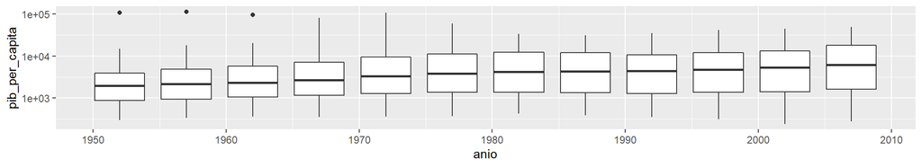

Se observa como los valores de las cajas suben, es decir, el PIB cada vez es mayor. Aunque parece que las cajas, cada vez son mas anchas.

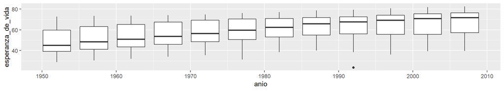

A su vez, la esperanza de vida también sube. El eje central de la caja cada vez se sitúa más en al parte superior de la caja.

## 1.4.2. GRÁFICO DE DISPERSIÓN DE PAÍSES

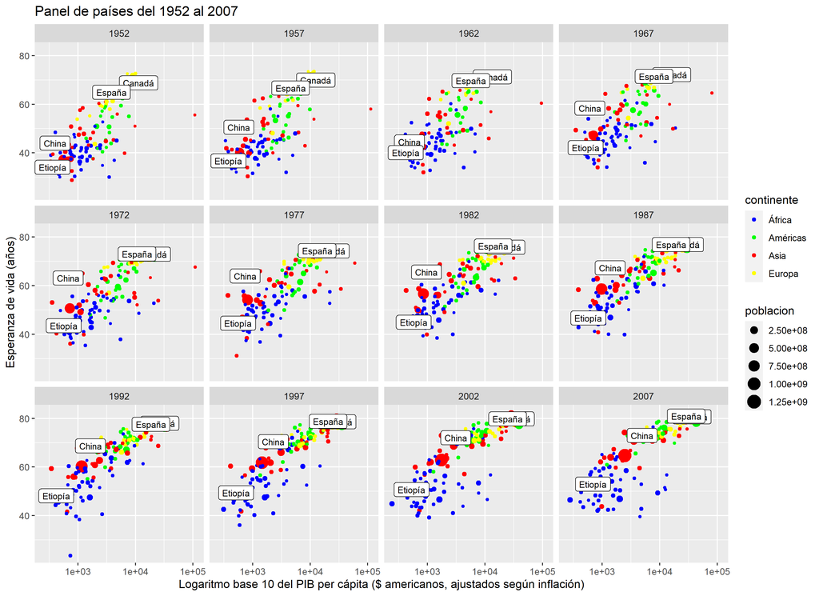

Panel países (Fuente: Elaboración propia con datos de Gapminder)

Se observa una clara relación entre tener un mayor PIB per cápita (logaritmo base 10) y la esperanza de vida media de los países.

Se observa como África siempre ha estado a la cola (menor PIB y menor esperanza de vida) y Europa a la cabeza. Se observa como Asia y América en su conjunto, han ido subiendo posiciones tanto en PIB, como en esperanza de vida.

Vemos como España y Canadá siempre han estado en la parte superior y Etiopía en la parte inferior en PIB per cápita y esperanza de vida. En cambio, China ha evolucionado positivamente en estos dos aspectos, pasando de la parte inferior a la parte superior de la nube de países.

## 1.4.3. TABLA DESCRIPTIVA DE PAÍSES

Resumen (Fuente: Elaboración propia con datos de Gapminder)

|  | anio | continente | esperanza_de_vida | pib_per_capita |
| --- | --- | --- | --- | --- |
|  | Min. :1952 | África :624 | Min. :23.60 | Min. : 241.2 |
|  | 1st Qu.:1966 | Américas:300 | 1st Qu.:48.20 | 1st Qu.: 1202.1 |
|  | Median :1980 | Asia :420 | Median :60.71 | Median : 3531.8 |
|  | Mean :1980 | Europa :360 | Mean :59.47 | Mean : 7215.3 |
|  | 3rd Qu.:1993 | NA | 3rd Qu.:70.85 | 3rd Qu.: 9325.5 |
|  | Max. :2007 | NA | Max. :82.60 | Max. :113523.1 |